# Lecture 5

Key Machine Learning Concepts - Explained wth Linear Regression  
Academic Year 1447  
Term 1  
Dr. Jomana Bashatah  
Slides adapted from Casten Lange

## Loading Required Libraries

```r
library(tidymodels)
library(rio)
library(kableExtra)
library(janitor)
library(shiny)
DataMockup = import("https://raw.githubusercontent.com/jomanab-cloud/ISE351-25-Presentations/afba6ed1275d81610b8b4214e765fac73046b2cb/DataStudyTimeMockup.rds")
```

### Learning Objectives

- Reviewing the basic idea behind linear regression
- Learning how how to measure predictive quality with Mean Square Error (MSE).
- Understanding the role of parameters in a machine learning model in general and in linear regression in particular
- Calculating optimal regression parameters using OLS
- Finding optimal regression parameters by trial and error
- Distinguish between unfitted and fitted models
- Using the `tidymodels` package to split observations from a dataset randomly into a training and testing dataset.
- Understanding how categorical data such as the gender of a person (female/male) can be transformed into numerical dummy variable.
- Being able to distinguish between dummy encoding and one-hot encoding
- Using `tidymodels` including model design and data pre-processing (recipes) to analyze housing prices.

## Jumping Right Into It

### Univariate OLS With a Real World Example

#### Data Description

- King County House Sale dataset (Kaggle 2015). House sales prices from May 2014 to May 2015 for King County in Washington State.
- Several predictor variables. For now we use only $\mathit{Sqft}$
- We will only use 100 randomly chosen observations from the total of 21,613 observations.
- We only use Sqft as predictor variable for now.

### Loading the Data and Assigning Training and Testing Data (Manually)

```r
DataHouses=
  import("https://raw.githubusercontent.com/jomanab-cloud/ISE351-25-Presentations/80f7609c6bcb4887517dcaff62908459cee33e33/HousingData.csv") |>
  clean_names("upper_camel") |>
  select(Price, Sqft=SqftLiving)

# Manually generating DataTrain and DataTest
set.seed(7771)
DataTrain= sample_n(DataHouses, 100)
DataTest= sample_n(DataHouses, 50)
head(DataTrain)
```

```
   Price Sqft
1 517000 1180
2 236000 1300
3 490000 2800
4 129000 1150
5 257000 1400
6 312500  870
```

## How Much is a House Worth in King County

### A house with average properties should be predicted with an average price!

```r
MeanSqft=mean(DataTrain$Sqft)
cat("The mean square footage of a house in King county is:", MeanSqft)
```

```
The mean square footage of a house in King county is: 1956.7
```

```r
MeanPrice=mean(DataTrain$Price)
cat("The mean price of a house in King county is:", MeanPrice)
```

```
The mean price of a house in King county is: 521294.2
```

## Predicting the Price of an Average Sized House as the Average of all House Prices

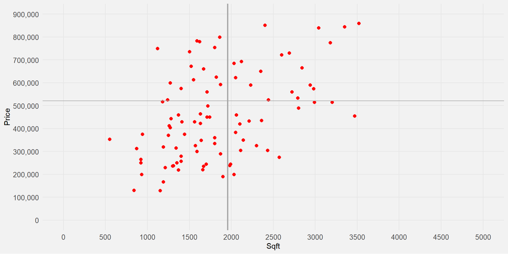

## From Unfitted to Fitted Model

### How Does the Unfitted Model Looks Like

$$\underbrace{\widehat{Price}}_{\hat{y}} = \underbrace{\beta_1}_{m} \underbrace{Sqft}_{x} + \underbrace{\beta_0}_{b}$$

### Fitting the Model with Tidymodels

```r
RecipeHouses= recipe(Price~Sqft, data=DataTrain)

ModelDesignOLS= linear_reg() %>%
                set_engine("lm") %>%
                set_mode("regression")

WFModelHouses = workflow() %>%
  add_recipe(RecipeHouses) %>%
  add_model(ModelDesignOLS) %>%
  fit(DataTrain)

tidy(WFModelHouses)
```

```
# A tibble: 2 × 5
  term        estimate std.error statistic  p.value
  <chr>          <dbl>     <dbl>     <dbl>    <dbl>
1 (Intercept)   52509.   64183.      0.818 4.15e- 1
2 Sqft            240.      30.6     7.84  5.67e-12
```

## Unfitted Model VS Fitted Workflow Model

### Unfitted Model:

$$\underbrace{\widehat{Price}}_{\hat{y}} = \underbrace{\beta_1}_{m} \underbrace{Sqft}_{x} + \underbrace{\beta_0}_{b}$$

```r
tidy(WFModelHouses)
```

```
# A tibble: 2 × 5
  term        estimate std.error statistic  p.value
  <chr>          <dbl>     <dbl>     <dbl>    <dbl>
1 (Intercept)   52509.   64183.      0.818 4.15e- 1
2 Sqft            240.      30.6     7.84  5.67e-12
```

### Fitted Model:

$$\underbrace{\widehat{Price}}_{\hat{y}} = \underbrace{240}_{m} \underbrace{Sqft}_{x} + \underbrace{52509}_{b}$$

## Interpretation and Significance

```
# A tibble: 2 × 5
  term        estimate std.error statistic  p.value
  <chr>          <dbl>     <dbl>     <dbl>    <dbl>
1 (Intercept)   52509.   64183.      0.818 4.15e- 1
2 Sqft            240.      30.6     7.84  5.67e-12
```

$$\widehat{\mathit{Price}} = 240 \cdot \mathit{Sqft} + 52509$$

$$\begin{aligned}
(+240) &= 240 \cdot (+1) + (+0) \\
(+480) &= 240 \cdot (+2) + (+0) \\
(+720) &= 240 \cdot (+3) + (+0)
\end{aligned}$$

**For each extra** $\mathit{Sqft}$ the predicted price increases by $240

**The variable** $\mathit{Sqft}$ is significant. I.e., the probability that the related coefficient $\beta_1$ equals zero is extremely small.

## Evaluating Predictive Quality with the Testing Dataset

```r
DataTestWithPred=augment(WFModelHouses, new_data=DataTest)
metrics(DataTestWithPred, truth=Price, estimate=.pred)
```

```
# A tibble: 3 × 3
  .metric .estimator  .estimate
  <chr>   <chr>           <dbl>
1 rmse    standard   163476.
2 rsq     standard        0.626
3 mae     standard   132050.
```

## Univariate Linear Regression - Data Table and Goal

### The Regression:

$$\hat{y}_i = \beta_1 x_i + \beta_2$$

### The Goal

Find values for $\beta_1$ and $\beta_2$ that minimize the prediction errors $(y_i - \hat{y}_i)^2$

### The Data Table

**Mockup Training Dataset**

| i | y Grade | x StudyTime |
| --- | --- | --- |
| 1 | 65 | 2 |
| 2 | 82 | 3 |
| 3 | 93 | 7 |
| 4 | 93 | 8 |
| 5 | 83 | 4 |

## Univariate Linear Regression - Data Diagram and Goal

### The Regression:

$$\hat{y}_i = \beta_1 x_i + \beta_2$$

### The Goal

Find values for $\beta_1$ and $\beta_2$ that minimize the prediction errors $(y_i - \hat{y}_i)^2$

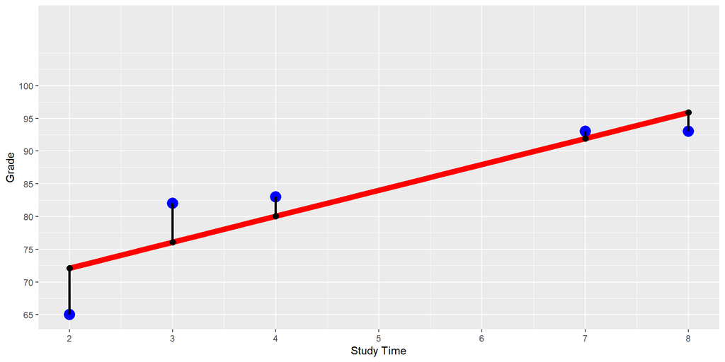

```r
Model123=lm(Grade~StudyTime, data=DataMockup)
PredGrade=predict(Model123, DataMockup)
ggplot(DataMockup, aes(x=StudyTime,y=Grade)) +
  geom_line(aes(y=PredGrade), color="red", size=2.7)+
  geom_point(size=5, color="blue")+
  geom_point(aes(y=PredGrade), color="black", size=2.7)+
  geom_segment(aes(x = StudyTime, y = PredGrade,
                   xend = StudyTime, yend = Grade),size=1.2)+
  scale_x_continuous("Study Time", breaks=seq(1,8))+
  scale_y_continuous(limits=c(65,110), breaks=seq(60,100,5))
```

## How to Measure Prediction Quality

$$MSE = \frac{1}{N} \sum_{i=1}^{N} (\hat{y}_i - y_i)^2$$

$$\Longleftrightarrow$$

$$MSE = \frac{1}{N} \sum_{i=1}^{N} \underbrace{(\overbrace{\beta_1 x_i + \beta_2}^{\substack{\text{Prediction} \\ i}} - y_i)^2}_{\substack{\text{Error} \\ i}}$$

**Note:** when the data are given (i.e., $x_i$ and $y_i$ are given), the $\mathit{MSE}$ depends only on the choice of $\beta_1$ and $\beta_2$

## How to Measure Prediction Quality with the MSE

$$\mathit{MSE} = \frac{(\beta_1 x_1 + \beta_2 - y_1)^2 + (\beta_1 x_2 + \beta_2 - y_2)^2 + \cdots + (\beta_1 x_5 + \beta_2 - y_5)^2}{5}$$

$$\Longleftrightarrow$$

$$\mathit{MSE} = \frac{1}{5} \left[ \underbrace{(\overbrace{\beta_1 \cdot 2 + \beta_2}^{\text{Prediction 1}} - 65)^2}_{\text{Error 1}} + \underbrace{(\overbrace{\beta_1 \cdot 3 + \beta_2}^{\text{Prediction 2}} - 82)^2}_{\text{Error 2}} \right.$$
$$\left. + \underbrace{(\overbrace{\beta_1 \cdot 7 + \beta_2}^{\text{Prediction 3}} - 93)^2}_{\text{Error 3}} + \underbrace{(\overbrace{\beta_1 \cdot 8 + \beta_2}^{\text{Prediction 4}} - 93)^2}_{\text{Error 4}} \right.$$

$$\left. + \underbrace{(\overbrace{\beta_1 \cdot 4 + \beta_2}^{\text{Prediction 5}} - 83)^2}_{\text{Error 5}} \right]$$

## Custom R Function to Calculate MSE

Function Call:

```r
library(rio)
FctMSE = import("https://raw.githubusercontent.com/jomanab-cloud/ISE351-25-Presentations/ae02842f37d063b3a1b7f70f57bee0ade556e482/FctMSE.rds")
VecBetaTest=c(4,61)
ResultMSE=FctMSE(VecBetaTest, DataMockup)
print(ResultMSE)
```

```
[1] 29.8
```

Function Definition:

```r
FctMSE=function(VecBeta, data){
                        Beta1=VecBeta[1]
                        Beta2=VecBeta[2]
                        data=data |>
                        rename(Y=1, X=2) |>
                        mutate(YPred=Beta1*X+Beta2) |>
                        mutate(Error=YPred-Y) |>
                        mutate(ErrorSqt=Error^2)

                        MSE=mean(data$ErrorSqt)

                        return(MSE)}
```

## How to Find Optimal Values for $\beta_1$ AND $\beta_2$

### Method 1:

**Calculate optimal values** for the parameters (the $\beta$s) based on Ordinary Least Squares (OLS) using two formulas (**Note**, this method works only for linear regression)

### Method 2:

We can use a **systematic trial and error process**.

## Method 1: Calculate Optimal Parameters (Only for OLS)

$$\beta_{1,opt} = \frac{N \sum_{i=1}^{N} y_i x_i - \sum_{i=1}^{N} y_i \sum_{i=1}^{N} x_i}{N \sum_{i=1}^{N} x_i^2 - \left(\sum_{i=1}^{N} x_i\right)^2} = 3.96$$

$$\beta_{2,opt} = \frac{\sum_{i=1}^{N} y_i - \beta_1 \sum_{i=1}^{N} x_i}{N} = 64.18$$

```r
DataTable=DataMockup |>
  mutate(GradeXStudyTime=Grade*StudyTime) |>
  mutate(StudyTimeSquared=StudyTime^2)


kbl(DataTable |> mutate(i=1:5) |> select(i,everything()),
    caption="Mockup Training Dataset ")|>
  add_header_above(c(" ", "y", "x", "y x","x x"), escape=F) |>
  kable_styling(bootstrap_options=c("striped","hover"), full_width = F, position="center")
```

Mockup Training Dataset

| i | y Grade | x StudyTime | y x GradeXStudyTime | x x StudyTimeSquared |
| --- | --- | --- | --- | --- |
| 1 | 65 | 2 | 130 | 4 |
| 2 | 82 | 3 | 246 | 9 |
| 3 | 93 | 7 | 651 | 49 |
| 4 | 93 | 8 | 744 | 64 |
| 5 | 83 | 4 | 332 | 16 |

Column Sums

| Grade | StudyTime | GradeXStudyTime | StudyTimeSquared |
| --- | --- | --- | --- |
| 416 | 24 | 2103 | 142 |

## Finding Optimal Values in R

1. Define and save the recipe that indicates which variable is the outcome and which is the predictor variable, together with the data argument.

Note that we do not add any step_ commands for data pre-processing since we can use the mockup data as is.

2. Define the model design in three steps that determine:
- The name of the machine learning model (linear_reg()).
- The R package used for that model (lm).
- The mode used—which is either “classification”or“regression”.
3. Add the recipe and the model design to the workflow and fit the workflow to the data.

```r
library(tidymodels)
RecipeMockup=recipe(Grade~StudyTime, data=DataMockup)
ModelDesignLinRegr=linear_reg() |>
set_engine("lm") |>
set_mode("regression")
WFModelMockup=workflow() |>
add_recipe(RecipeMockup) |>
add_model(ModelDesignLinRegr) |>
fit(DataMockup)
```

## Method 2: Use a Systematic Trial and Error Process

- Grid Search (aka Brute Force):
1. For a given range of $\mathit{β_1}$ and $\mathit{β_2}$ values, build a table with pairs of all combinations of these $\mathit{β_s}$
2. Then use our custom `FctMSE()` command to calculate a *MSE* for each $\mathit{β}$ pair.
3. Find the $\mathit{β}$ pair with the lowest *MSE*
- **Optimizer**: Use the R build-in optimizer. Push the start values for $\mathit{β_1}$ and $\mathit{β_2}$ together with the data to the optimizer as arguments. The rest is done by the optimizer.

# Multivariate OLS with a Real World Dataset

## Multivariate OLS with a Real World Dataset

### Data

```r
library(rio)
DataHousing =
  import("https://raw.githubusercontent.com/jomanab-cloud/ISE351-25-Presentations/f1259ac81b553bd18a1478f1f830c4e5e70647a9/HousingDataSmall.csv")
```

- King County House Sale dataset (Kaggle 2015). House sales prices from May 2014 to May 2015 for King County in Washington State.
- Several predictor variables.
- We will use all 21,613 observations.

## Multivariate Analysis — Three Predictor Variables

*Sqft:* Living square footage of the house

*Grade:* Indicates the condition of houses (1 (worst) to 13 (best))

*Waterfront:* Is house located at the waterfront (*yes* or *no*)

```r
library(tidyverse); library(rio); library(janitor); library(tidymodels)
DataHousing =
  import("https://raw.githubusercontent.com/jomanab-cloud/ISE351-25-Presentations/80f7609c6bcb4887517dcaff62908459cee33e33/HousingData.csv") |>
  clean_names("upper_camel") |>
  select(Price, Sqft=SqftLiving, Grade, Waterfront)
```

### Unfitted Model

$$Price = \beta_1 Sqft + \beta_2 Grade + \beta_3 Waterfront_{yes} + \beta_4$$

## Multivariate Real World Dataset — Splitting

```r
set.seed(777)
Split7030=initial_split(0.7,data=DataHousing, strata = Price, breaks = 5)
DataTrain=training(Split7030)
DataTest=testing(Split7030)
```

### DataTrain

```
   Price Sqft Grade Waterfront
1 221900 1180     7         no
2 180000  770     6         no
3 189000 1200     7         no
4 230000 1250     7         no
5 252700 1070     7         no
6 240000 1220     7         no
```

### DataTest

```
    Price Sqft Grade Waterfront
1 1230000 5420    11         no
2  257500 1715     7         no
3  291850 1060     7         no
4  229500 1780     7         no
5  530000 1810     7         no
6  650000 2950     9         no
```

## Dummy and One-Hot Encoding

### One-Hot Encoding

```r
OneHotTable=tibble(Waterfront_yes=c(0,0,1,0),Waterfront_no=c(1,1,0,1))
print(OneHotTable)
```

```
# A tibble: 4 × 2
  Waterfront_yes Waterfront_no
           <dbl>         <dbl>
1              0             1
2              0             1
3              1             0
4              0             1
```

*One-hot* encoding is easier to interpret but causes problems in OLS (dummy trap) because one variable is redundant. We can calculate one variable from the other (*perfect multicollinearity*):

$$\mathit{Waterfront}_{yes} = 1 - \mathit{Waterfront}_{no}$$

## Dummy and One-Hot Encoding

### Dummy Coding

We use one variable less than we have categories. Waterfront has two categories. Therefore, we use one variable (e.g., Waterfront_yes):

### Dummy Encoding Example

```r
DummyTable=tibble(Waterfront_yes=c(0,0,1,0))
print(DummyTable)
```

```
# A tibble: 4 × 1
  Waterfront_yes
           <dbl>
1              0
2              0
3              1
4              0
```

**Note**: dummy encoding can be done with step_dummy() in a tidymodels recipe.

## Multivariate Analysis — Building the Recipe

```r
RecipeHouses=recipe(Price ~ ., data=DataTrain) |>
                    step_dummy(Waterfront)
```

Here is how the recipe later on (in the workflow) transforms the data:

```r
juice(RecipeHouses |> prep()) |> head()
```

```
# A tibble: 6 × 4
   Sqft Grade  Price Waterfront_yes
  <int> <int>  <dbl>          <dbl>
1  1180     7 221900              0
2   770     6 180000              0
3  1200     7 189000              0
4  1250     7 230000              0
5  1070     7 252700              0
6  1220     7 240000              0
```

## Multivariate Analysis — Building the Model Design

### Unfitted Model:

```r
ModelDesignHouses=linear_reg() |>
  set_engine("lm") |>
  set_mode("regression")
print(ModelDesignHouses)
```

```
Linear Regression Model Specification (regression)

Computational engine: lm
```

## Multivariate Analysis — Creating Workflow & Fitting to the Training Data

```r
WFModelHouses = workflow() |>
      add_recipe(RecipeHouses) |>
      add_model(ModelDesignHouses) |>
      fit(DataTrain)
tidy(WFModelHouses)
```

```
# A tibble: 4 × 5
  term           estimate std.error statistic   p.value
  <chr>             <dbl>     <dbl>     <dbl>     <dbl>
1 (Intercept)    -570056.  15133.       -37.7 6.63e-297
2 Sqft               180.      3.25      55.2 0
3 Grade            95214.   2548.        37.4 1.65e-292
4 Waterfront_yes  868338.  22200.        39.1 7.12e-319
```

```r
glance(WFModelHouses)
```

```
# A tibble: 1 × 12
  r.squared adj.r.squared   sigma statistic p.value    df   logLik    AIC    BIC
      <dbl>         <dbl>   <dbl>     <dbl>   <dbl> <dbl>    <dbl>  <dbl>  <dbl>
1     0.581         0.581 238574.     7002.       0     3 -208785. 4.18e5 4.18e5
# ℹ 3 more variables: deviance <dbl>, df.residual <int>, nobs <int>
```

## Multivariate Analysis — Predicting Testing Data and Metrics

```r
DataTestWithPredictions = augment(WFModelHouses, new_data=DataTest)
metrics(DataTestWithPredictions, truth=Price, estimate=.pred)
```

```
# A tibble: 3 × 3
  .metric .estimator  .estimate
  <chr>   <chr>           <dbl>
1 rmse    standard   244656.
2 rsq     standard        0.549
3 mae     standard   163358.
```

## Exercise

Let’s Run the Analysis

[Download: 05-LinRegrExerc100.Rmd](https://github.com/jomanab-cloud/ISE351-25-Presentations/blob/4d3d9ca2629b5d3873c53ff4a10be3844473bf6d/05-LinRegrExerc100.Rmd)